# Homework 03

## Question 1: Build an `explain-to-me` skill

Create a small skill named `explain-to-me` that helps you understand a homework question.

1. Design your `SKILL.md` file so that, when you explicitly ask your agent to use the skill to read a homework question, the agent communicates with you and explains what the question is asking.
2. Keep the skill file short. It should contain a few useful rules, instructions, and a clear statement of your intent. For example, you may ask the agent to explain the goal of the question, clarify what work is required, and point you to an appropriate section of the Week 3 lectures: [Ridge Regression: Stability Through Shrinkage](https://teazrq.github.io/stat432rpy/topics/ridge-regression/ridge-regression.html) or [From a Penalized Objective to a Fitted Ridge Model](https://teazrq.github.io/stat432rpy/topics/ridge-regression/optimization-and-cross-validation.html). The skill should help you understand the question without completing the solution for you.
3. Create the skill yourself or with the help of AI. Save it as `explain-to-me/SKILL.md`. Then ask your AI agent to install the skill using its normal skill-installation method. Test it by explicitly asking the agent to use `explain-to-me` to read and explain Question 2.
4. If the skill does not work well, or if it begins to disturb your usual workflow, ask your agent to remove the installed skill. You may revise and reinstall it if you wish.
5. In all cases, append the complete contents of your developed `explain-to-me/SKILL.md` file at the end of your Homework 3 submission under the heading **`explain-to-me` skill**.

The complete file appears at the end of this submission under **`explain-to-me` skill**

## Question 2: Ridge regression with nearly collinear predictors

Let $n=100$. Generate mutually independent standard normal random variables

$$L_i, U_{i1}, U_{i2}, X_{i3}, X_{i4},
\qquad i=1,\ldots,n,$$

and define

$$X_{i1}=L_i+0.04U_{i1},
\qquad
X_{i2}=L_i+0.04U_{i2}.$$

Center and standardize each column of $\mathbf X$ to have mean zero and average squared value one, following the [lecture’s scaling convention](https://teazrq.github.io/stat432rpy/topics/ridge-regression/ridge-regression.html#put-every-covariate-on-a-common-scale).

Continue to use $\mathbf X\in\mathbb R^{n\times p}$ for the standardized matrix and keep it fixed throughout the question, where $p=4$ is the number of predictors. The unpenalized intercept gives $p+1=5$ total fitted coefficients. Let

$$\boldsymbol\beta
=
(1.5,1.5,1,0)^{\mathsf T},
\qquad
\boldsymbol\mu
=
\mathbf X\boldsymbol\beta.$$

Generate a training response and an independent test response at the same predictor values:

$$\begin{aligned}
\mathbf y
&=
\boldsymbol\mu+\boldsymbol\epsilon,\\
\mathbf y^*
&=
\boldsymbol\mu+\boldsymbol\epsilon^*,
\end{aligned}$$

where

$$\boldsymbol\epsilon,
\boldsymbol\epsilon^*
\overset{\mathrm{ind}}{\sim}
\mathcal N_n(\mathbf0,\mathbf I_n).$$

Center the training response as $\widetilde{\mathbf y}=\mathbf y-\bar y\mathbf1_n$. For each $\lambda\in\{0,0.02,0.2\}$, fit the slopes using the lecture’s ridge formula:

$$\widehat{\boldsymbol\beta}_\lambda
=
\left(\mathbf X^{\mathsf T}\mathbf X+n\lambda\mathbf I_p\right)^{-1}
\mathbf X^{\mathsf T}\widetilde{\mathbf y}.$$

The unpenalized intercept is $\widehat\beta_0=\bar y$; add this training mean back when predicting either response. The case $\lambda=0$ is ordinary least squares. Use seed `43231` before generating the design and responses. R and Python use different random-number generators, so their exact numerical results need not agree.

1. Generate $\mathbf X$ once. Report the correlation between its first two columns and its largest and smallest singular values. Use these quantities to explain why the estimator contrast $\widehat\beta_1-\widehat\beta_2$ should be much more variable than $\widehat\beta_1+\widehat\beta_2$.

**Show the workflow**

```python
import numpy as np
import pandas as pd

rng = np.random.default_rng(43231)
n, p, repetitions = 100, 4, 200

# Generate the design once and keep it fixed for the whole question.
L = rng.normal(size=n)
U1 = rng.normal(size=n)
U2 = rng.normal(size=n)
X = np.column_stack(
    (L + 0.04 * U1, L + 0.04 * U2, rng.normal(size=n), rng.normal(size=n))
)

# Lecture scaling: mean zero, average squared value one.
X = X - X.mean(axis=0)
X = X / np.sqrt(np.mean(X**2, axis=0))

beta = np.array([1.5, 1.5, 1.0, 0.0])
mu = X @ beta
lambda_grid = np.array([0.0, 0.02, 0.2])

singular_values = np.linalg.svd(X, compute_uv=False)
print(
    pd.Series(
        {
            "correlation": np.corrcoef(X[:, 0], X[:, 1])[0, 1],
            "largest_singular_value": singular_values.max(),
            "smallest_singular_value": singular_values.min(),
            "condition_number": singular_values.max() / singular_values.min(),
        }
    ).round(4)
)

# Exact OLS standard deviations of the two contrasts when sigma = 1,
# alongside how far each direction moves the fitted values.
gram_inverse = np.linalg.inv(X.T @ X)
a_sum = np.array([1.0, 1.0, 0.0, 0.0])
a_difference = np.array([1.0, -1.0, 0.0, 0.0])

for label, a in [("sum", a_sum), ("difference", a_difference)]:
    sd = np.sqrt(a @ gram_inverse @ a)
    print(f"{label:>10}: sd = {sd:.4f}, ||X a|| = {np.linalg.norm(X @ a):.4f}")
```

```
correlation                 0.9983
largest_singular_value     14.1730
smallest_singular_value     0.4061
condition_number           34.9007
dtype: float64
       sum: sd = 0.1003, ||X a|| = 19.9917
difference: sd = 3.4824, ||X a|| = 0.5775
```

**Answer.** The correlation between the first two standardized columns is $0.9983$. The singular values of $\mathbf X$ are $14.173$, $10.646$, $9.253$, and $0.406$, so $d_{\max}=14.173$ and $d_{\min}=0.406$, giving a condition number of $d_{\max}/d_{\min}\approx34.9$.

Both columns are built from the same latent $L_i$ plus noise of standard deviation $0.04$, so they carry nearly the same information. That shows up geometrically: $\lVert\mathbf X(1,1,0,0)^{\mathsf T}\rVert_2=19.99$, while $\lVert\mathbf X(1,-1,0,0)^{\mathsf T}\rVert_2=0.578$. Moving along the sum direction changes the fitted values a great deal; moving along the difference direction changes them almost not at all.

For OLS with $\operatorname{Var}(\boldsymbol\epsilon)=\sigma^2\mathbf I_n$, any linear contrast satisfies

$$\operatorname{Var}\!\left(\mathbf a^{\mathsf T}\widehat{\boldsymbol\beta}\right)
=
\sigma^2
\mathbf a^{\mathsf T}
\left(\mathbf X^{\mathsf T}\mathbf X\right)^{-1}
\mathbf a
=
\sigma^2
\sum_{j=1}^p
\frac{\left(\mathbf v_j^{\mathsf T}\mathbf a\right)^2}{d_j^2}.$$

The variance is governed by which singular directions the contrast loads on, and each direction enters with weight $1/d_j^2$. Here $(1,-1,0,0)^{\mathsf T}$ lies almost entirely along $\mathbf v_4$, with $d_4=0.406$, and $(1,1,0,0)^{\mathsf T}$ lies almost entirely along $\mathbf v_1$, with $d_1=14.173$. Substituting gives standard deviations of $3.482$ and $0.100$ when $\sigma=1$. Their ratio, $34.7$, is essentially the condition number, since dividing by $d_4^2$ rather than $d_1^2$ inflates the variance by $(d_1/d_4)^2$.

The difference should therefore be roughly $35$ times more variable than the sum. The data pin down $\beta_1+\beta_2$ tightly but say almost nothing about how that total splits between two nearly identical predictors.

2. Independently repeat the generation of $\mathbf y$ and $\mathbf y^*$, followed by all three fits, 200 times while keeping $\mathbf X$ fixed. Draw the training and test noise inside each repetition, then reuse that realized pair for all three values of $\lambda$. For each value of $\lambda$, report the empirical mean and standard deviation of

$$\widehat\beta_1,
\quad
\widehat\beta_2,
\quad
\widehat\beta_1+\widehat\beta_2,
\quad
\widehat\beta_1-\widehat\beta_2.$$

Also report the average training MSE and the average test MSE calculated from the independent test response, where

$$\operatorname{MSE}_{\mathrm{test}}
=
\frac{1}{n}
\left\lVert
\mathbf y^*
-
\widehat\beta_0\mathbf1_n
-
\mathbf X\widehat{\boldsymbol\beta}
\right\rVert_2^2.$$

**Show the workflow**

```python
# Axes: repetitions, coefficients, penalties.
beta_hat = np.empty((repetitions, p, len(lambda_grid)))
train_mse = np.empty((repetitions, len(lambda_grid)))
test_mse = np.empty((repetitions, len(lambda_grid)))

for k in range(repetitions):
    # One training and one test response per repetition, reused for all penalties.
    y = mu + rng.normal(size=n)
    y_test = mu + rng.normal(size=n)
    y_centered = y - y.mean()

    for l, lam in enumerate(lambda_grid):
        beta_hat[k, :, l] = np.linalg.solve(
            X.T @ X + n * lam * np.eye(p),
            X.T @ y_centered,
        )
        y_hat = y.mean() + X @ beta_hat[k, :, l]
        train_mse[k, l] = np.mean((y - y_hat) ** 2)
        test_mse[k, l] = np.mean((y_test - y_hat) ** 2)

coefficient_rows = []
for l, lam in enumerate(lambda_grid):
    b1, b2 = beta_hat[:, 0, l], beta_hat[:, 1, l]
    coefficient_rows.append(
        {
            "lambda": lam,
            "beta1": f"{b1.mean():.3f} ({b1.std(ddof=1):.3f})",
            "beta2": f"{b2.mean():.3f} ({b2.std(ddof=1):.3f})",
            "sum": f"{(b1 + b2).mean():.3f} ({(b1 + b2).std(ddof=1):.3f})",
            "difference": f"{(b1 - b2).mean():.3f} ({(b1 - b2).std(ddof=1):.3f})",
        }
    )

error_summary = pd.DataFrame(
    {
        "lambda": lambda_grid,
        "training_mse": train_mse.mean(axis=0),
        "test_mse": test_mse.mean(axis=0),
    }
)

print(pd.DataFrame(coefficient_rows).to_string(index=False))
print()
print(error_summary.round(3).to_string(index=False))
```

```
 lambda         beta1         beta2           sum     difference
   0.00 1.290 (1.795) 1.701 (1.798) 2.992 (0.105) -0.411 (3.592)
   0.02 1.465 (0.145) 1.497 (0.148) 2.961 (0.104) -0.032 (0.274)
   0.20 1.355 (0.049) 1.359 (0.050) 2.715 (0.095) -0.004 (0.029)

 lambda  training_mse  test_mse
   0.00         0.949     1.038
   0.02         0.960     1.029
   0.20         1.064     1.125
```

**Answer.** Empirical mean with standard deviation in parentheses, over 200 repetitions:

| $\lambda$ | $\widehat\beta_1$ | $\widehat\beta_2$ | $\widehat\beta_1+\widehat\beta_2$ | $\widehat\beta_1-\widehat\beta_2$ |
| --- | --- | --- | --- | --- |
| 0.00 | 1.290 (1.795) | 1.701 (1.798) | 2.992 (0.105) | -0.411 (3.592) |
| 0.02 | 1.465 (0.145) | 1.497 (0.148) | 2.961 (0.104) | -0.032 (0.274) |
| 0.20 | 1.355 (0.049) | 1.359 (0.050) | 2.715 (0.095) | -0.004 (0.029) |

Average training and test MSE:

| $\lambda$ | Training MSE | Test MSE |
| --- | --- | --- |
| 0.00 | 0.949 | 1.038 |
| 0.02 | 0.960 | 1.029 |
| 0.20 | 1.064 | 1.125 |

The simulated OLS standard deviations, $0.105$ for the sum and $3.592$ for the difference, match the theoretical values of $0.100$ and $3.482$ predicted in part (a). Setting $\lambda=0.02$ cuts the standard deviation of the difference by a factor of $13$ while leaving the sum essentially unchanged at $0.104$. The larger penalty $\lambda=0.2$ removes almost all remaining variability but pulls the mean of the sum down to $2.715$, well below its true value of $3$.

3. Interpret the coefficient estimates and test MSE using bias and variance. Explain why ridge can substantially stabilize the individual coefficients without producing an equally large change in the fitted values.

**Answer.** OLS is unbiased, and the table shows it: the sum averages $2.992$ against a true value of $3$, and the individual coefficients average near $1.5$. What OLS lacks is stability. Its individual coefficients have standard deviations near $1.8$, larger than the coefficients themselves, so a single realization can easily report $\widehat\beta_1=-0.5$ and $\widehat\beta_2=3.5$. Almost all of that variance sits in the difference direction.

Ridge trades that variance for bias. At $\lambda=0.02$ the bias is still small, since the sum moves only from $2.992$ to $2.961$, while the standard deviation of each coefficient falls from about $1.8$ to about $0.15$. At $\lambda=0.2$ the variance is smaller again, but the sum has been pulled to $2.715$ and bias now dominates.

The test MSE follows the standard decomposition. Because $\mathbf y^*$ is an independent draw at the same design,

$$\mathbb E\left[\operatorname{MSE}_{\mathrm{test}}\right]
=
\underbrace{\sigma^2}_{1.000}
+
\frac{1}{n}
\left\lVert
\mathbb E\left[\mathbf X\widehat{\boldsymbol\beta}_\lambda\right]-\boldsymbol\mu
\right\rVert_2^2
+
\frac{1}{n}
\sum_{i=1}^n
\operatorname{Var}\!\left(\mathbf x_i^{\mathsf T}\widehat{\boldsymbol\beta}_\lambda\right).$$

Estimating the two middle terms across the 200 repetitions gives

| $\lambda$ | Irreducible | Squared bias | Variance | Total | Observed test MSE |
| --- | --- | --- | --- | --- | --- |
| 0.00 | 1.000 | 0.000 | 0.039 | 1.039 | 1.038 |
| 0.02 | 1.000 | 0.002 | 0.027 | 1.029 | 1.029 |
| 0.20 | 1.000 | 0.109 | 0.021 | 1.130 | 1.125 |

The mild penalty buys a variance reduction of $0.012$ for a bias cost of $0.002$ and wins. The strong penalty buys a further variance reduction of only $0.006$ for a bias cost of $0.107$ and loses. Training MSE rises monotonically with $\lambda$, which is why it cannot be used to choose the penalty.

Ridge stabilizes coefficients far more than fitted values because the two live on different scales in the weak direction. Ridge multiplies the $j$th singular direction by $d_j^2/(d_j^2+n\lambda)$. With $n\lambda=2$ at $\lambda=0.02$, those factors are

$$0.990,
\qquad
0.983,
\qquad
0.977,
\qquad
0.076 .$$

The three well-determined directions are left almost untouched, and the weak fourth direction is cut to $7.6\%$ of its least-squares value. That fourth direction is exactly where the unstable difference lives, so the coefficient contrast collapses from a standard deviation of $3.592$ to $0.274$.

The fitted values barely notice, because $\mathbf X$ maps that direction to a vector of length $d_4=0.406$ rather than $d_1=14.173$. A change of size $\delta$ in $\widehat\beta_1-\widehat\beta_2$ moves $\mathbf X\widehat{\boldsymbol\beta}$ by only about $0.406\,\delta/\sqrt2$. Large corrections in coefficient space are small corrections in prediction space. The same arithmetic drops the effective degrees of freedom from $5$ to $4.03$ at $\lambda=0.02$ while the average test MSE improves only from $1.038$ to $1.029$.

## Question 3: What does ridge regression shrink?

Let $\mathbf X\in\mathbb R^{n\times p}$ be a centered predictor matrix, and let $\widetilde{\mathbf y}\in\mathbb R^n$ be the centered response. Use the supplied predictor scales for this algebraic question; the columns need not have unit variance. Here $p$ counts predictors, $\boldsymbol\beta\in\mathbb R^p$ contains their slopes, and $p+1$ counts all fitted coefficients, including the separately fitted, unpenalized intercept. Ridge regression minimizes

$$L_\lambda(\boldsymbol\beta)
=
\frac{1}{2n}
\left\lVert
\widetilde{\mathbf y}-\mathbf X\boldsymbol\beta
\right\rVert_2^2
+
\frac{\lambda}{2}
\lVert\boldsymbol\beta\rVert_2^2.$$

1. Derive the ridge normal equation

$$\left(
\mathbf X^{\mathsf T}\mathbf X
+n\lambda\mathbf I_p
\right)
\widehat{\boldsymbol\beta}_\lambda
=
\mathbf X^{\mathsf T}\widetilde{\mathbf y}.$$

Explain why it has a unique solution whenever $\lambda>0$, even if $\mathbf X$ is rank deficient or $p>n$.

**Answer.** Differentiating the objective with respect to $\boldsymbol\beta$ gives

$$\nabla L_\lambda(\boldsymbol\beta)
=
-\frac{1}{n}
\mathbf X^{\mathsf T}
\left(\widetilde{\mathbf y}-\mathbf X\boldsymbol\beta\right)
+
\lambda\boldsymbol\beta .$$

Setting the gradient to zero at $\widehat{\boldsymbol\beta}_\lambda$ gives

$$\frac{1}{n}
\mathbf X^{\mathsf T}\mathbf X\widehat{\boldsymbol\beta}_\lambda
+
\lambda\widehat{\boldsymbol\beta}_\lambda
=
\frac{1}{n}
\mathbf X^{\mathsf T}\widetilde{\mathbf y},$$

and multiplying through by $n$ yields the stated normal equation, hence

$$\widehat{\boldsymbol\beta}_\lambda
=
\left(\mathbf X^{\mathsf T}\mathbf X+n\lambda\mathbf I_p\right)^{-1}
\mathbf X^{\mathsf T}\widetilde{\mathbf y}.$$

The stationary point is the unique global minimum because the objective is strictly convex. For any nonzero $\mathbf a\in\mathbb R^p$,

$$\mathbf a^{\mathsf T}
\left(\mathbf X^{\mathsf T}\mathbf X+n\lambda\mathbf I_p\right)
\mathbf a
=
\lVert\mathbf X\mathbf a\rVert_2^2
+
n\lambda\lVert\mathbf a\rVert_2^2
>0
\qquad\text{whenever }\lambda>0 .$$

The first term is nonnegative and the second is strictly positive, so the Hessian $\frac1n\left(\mathbf X^{\mathsf T}\mathbf X+n\lambda\mathbf I_p\right)$ is positive definite and therefore invertible.

This argument never used the rank of $\mathbf X$. If $\mathbf X$ is rank deficient or $p>n$, then $\mathbf X^{\mathsf T}\mathbf X$ is singular and the OLS normal equation has infinitely many solutions, since any vector in the null space of $\mathbf X$ can be added without changing the fit. Every eigenvalue of $\mathbf X^{\mathsf T}\mathbf X$ is still nonnegative, so adding $n\lambda\mathbf I_p$ raises them all to at least $n\lambda>0$. The penalty supplies the curvature the data fail to provide, and among the infinitely many vectors that fit equally well it selects the one of smallest norm.

2. Let

$$\mathbf X
=
\mathbf U_r\mathbf D_r\mathbf V_r^{\mathsf T}$$

be a compact singular value decomposition, where $r=\operatorname{rank}(\mathbf X)$, $\mathbf U_r\in\mathbb R^{n\times r}$, $\mathbf D_r\in\mathbb R^{r\times r}$, and $\mathbf V_r\in\mathbb R^{p\times r}$. Show that ridge multiplies the fitted response component in the $j$th left singular-vector direction, for $j=1,\ldots,r$, by

$$\rho_j(\lambda)
=
\frac{d_j^2}{d_j^2+n\lambda}.$$

Suppose $n=100$, $\lambda=0.01$, and the nonzero singular values are

$$d_1=10,
\qquad
d_2=2,
\qquad
d_3=0.2.$$

Calculate the three shrinkage factors and the total effective degrees of freedom, including the unpenalized intercept:

$$\operatorname{df}_{\mathrm{eff}}(\lambda)
=
1+\sum_{j=1}^3\rho_j(\lambda).$$

**Answer.** Write $\mathbf X=\mathbf U_r\mathbf D_r\mathbf V_r^{\mathsf T}$ with $\mathbf U_r^{\mathsf T}\mathbf U_r=\mathbf V_r^{\mathsf T}\mathbf V_r=\mathbf I_r$. Then

$$\mathbf X^{\mathsf T}\mathbf X+n\lambda\mathbf I_p
=
\mathbf V_r\left(\mathbf D_r^2+n\lambda\mathbf I_r\right)\mathbf V_r^{\mathsf T}
+
n\lambda\left(\mathbf I_p-\mathbf V_r\mathbf V_r^{\mathsf T}\right).$$

The two terms act on orthogonal subspaces, so the inverse is obtained by inverting each separately. Since $\mathbf X^{\mathsf T}\widetilde{\mathbf y}=\mathbf V_r\mathbf D_r\mathbf U_r^{\mathsf T}\widetilde{\mathbf y}$ lies entirely in the column space of $\mathbf V_r$, the second term contributes nothing and

$$\widehat{\boldsymbol\beta}_\lambda
=
\mathbf V_r
\left(\mathbf D_r^2+n\lambda\mathbf I_r\right)^{-1}
\mathbf D_r
\mathbf U_r^{\mathsf T}\widetilde{\mathbf y}.$$

Any component of $\boldsymbol\beta$ orthogonal to the columns of $\mathbf V_r$ lies in the null space of $\mathbf X$; it would add to the penalty without changing the fit, so ridge sets it to zero. Multiplying by $\mathbf X$ gives the fitted response

$$\mathbf X\widehat{\boldsymbol\beta}_\lambda
=
\mathbf U_r\mathbf D_r
\left(\mathbf D_r^2+n\lambda\mathbf I_r\right)^{-1}
\mathbf D_r
\mathbf U_r^{\mathsf T}\widetilde{\mathbf y}
=
\sum_{j=1}^r
\frac{d_j^2}{d_j^2+n\lambda}
\,
\mathbf u_j\mathbf u_j^{\mathsf T}\widetilde{\mathbf y},$$

where the middle step uses the fact that $\mathbf D_r$ and $\left(\mathbf D_r^2+n\lambda\mathbf I_r\right)^{-1}$ are both diagonal. Since $\mathbf u_j\mathbf u_j^{\mathsf T}\widetilde{\mathbf y}$ is the component of $\widetilde{\mathbf y}$ along $\mathbf u_j$, ridge multiplies that component by

$$\rho_j(\lambda)=\frac{d_j^2}{d_j^2+n\lambda},$$

as claimed. Setting $\lambda=0$ gives $\rho_j=1$ and recovers the OLS projection onto the column space.

With $n=100$ and $\lambda=0.01$ the penalty enters as $n\lambda=1$, so

$$\begin{aligned}
\rho_1
&=
\frac{10^2}{10^2+1}
=
\frac{100}{101}
\approx0.9901,\\[2pt]
\rho_2
&=
\frac{2^2}{2^2+1}
=
\frac{4}{5}
=0.8000,\\[2pt]
\rho_3
&=
\frac{0.2^2}{0.2^2+1}
=
\frac{0.04}{1.04}
\approx0.0385 .
\end{aligned}$$

Including the unpenalized intercept,

$$\operatorname{df}_{\mathrm{eff}}(0.01)
=
1+0.9901+0.8000+0.0385
\approx
2.8286 .$$

The unpenalized fit would use $1+3=4$ degrees of freedom, so this penalty removes about $1.17$ of them, and roughly $0.96$ of that removal comes from the third direction alone.

3. Which direction receives the strongest shrinkage? Explain why shrinking this direction can reduce prediction variance. Under what circumstance could the same shrinkage produce substantial prediction bias?

**Answer.** The third direction receives by far the strongest shrinkage. Its component is retained at only $3.85\%$, against $80\%$ for the second and $99\%$ for the first. Shrinkage is strongest where $d_j$ is smallest, because $\rho_j$ increases in $d_j^2$ while $n\lambda$ is the same in every direction. The relevant comparison is $d_j^2$ against $n\lambda$: here $d_3^2=0.04$ sits far below $n\lambda=1$, while $d_1^2=100$ sits far above it.

Shrinking that direction reduces prediction variance because the variance contributed by direction $j$ is proportional to $\rho_j^2$. Under $\operatorname{Var}(\widetilde{\mathbf y})=\sigma^2\mathbf I_n$, the fitted coefficient along $\mathbf u_j$ has variance $\sigma^2\rho_j(\lambda)^2$, so the total variance of the fit is $\sigma^2\sum_j\rho_j^2$. A small singular value means the design barely varies in that direction, so the least-squares estimate of its coefficient is built from a small amount of signal and a full share of noise. In the corresponding coefficient direction the OLS variance is $\sigma^2/d_3^2=25\sigma^2$, against $0.01\sigma^2$ in the first direction. Multiplying by $\rho_3^2\approx0.00148$ cuts that contribution by a factor of about $675$. Discarding a direction the data cannot resolve costs little and removes a large amount of noise.

The same shrinkage produces substantial bias when the true mean response has a large component in that direction. The bias along $\mathbf u_j$ is

$$\left(1-\rho_j(\lambda)\right)\mathbf u_j^{\mathsf T}\boldsymbol\mu ,$$

Whether the trade is worthwhile depends on the signal-to-noise ratio in that direction, $\left(\mathbf u_j^{\mathsf T}\boldsymbol\mu\right)^2$ against $\sigma^2$. Shrinkage helps when that ratio is small and hurts when it is large. The quantity is unknown in practice, which is why $\lambda$ must be tuned from data rather than assumed.

## Question 4: Ridge regression and optimization

Let $\mathbf X\in\mathbb R^{n\times p}$ be a centered predictor matrix with $p=2$. Its columns need not have unit variance in this question. The intercept is fitted separately and is not penalized. Suppose the two eigenvalues of

$$\mathbf A_0
=
\frac{1}{n}\mathbf X^{\mathsf T}\mathbf X$$

are $9$ and $0.01$. Ridge regression with $\lambda=0.09$ has curvature matrix

$$\mathbf A_\lambda
=
\frac{1}{n}\mathbf X^{\mathsf T}\mathbf X
+
\lambda\mathbf I_p.$$

1. Calculate the condition numbers of $\mathbf A_0$ and $\mathbf A_\lambda$. Explain what the change says about the geometry of the ridge objective.

**Answer.** Adding $\lambda\mathbf I_p$ leaves the eigenvectors unchanged and shifts every eigenvalue by $\lambda$, so the eigenvalues of $\mathbf A_\lambda$ are $9+0.09=9.09$ and $0.01+0.09=0.10$. The condition numbers are

$$\kappa(\mathbf A_0)
=
\frac{9}{0.01}
=900,
\qquad
\kappa(\mathbf A_\lambda)
=
\frac{9.09}{0.10}
=90.9 .$$

The penalty improves the conditioning by a factor of about ten. Geometrically, the contours of a quadratic objective are ellipses whose axis lengths scale as $1/\sqrt{a_i}$ for eigenvalue $a_i$. Under $\mathbf A_0$ the axis ratio is $\sqrt{900}=30$, so the level sets form a long narrow valley: the objective rises steeply across the valley and is nearly flat along it. Under $\mathbf A_\lambda$ that ratio falls to $\sqrt{90.9}\approx9.5$.

The shift matters almost entirely in the flat direction. The small eigenvalue is multiplied by ten, from $0.01$ to $0.10$, while the large one barely moves, from $9$ to $9.09$. Ridge adds curvature where the data provide almost none, which is the same fact that makes the estimator stable, since a direction with little curvature is a direction in which the fit is poorly determined. The contours remain elongated, so the problem is not perfectly conditioned, but a gradient method now makes far better progress along the weak direction.

2. Gradient descent uses

$$\boldsymbol\beta^{(k+1)}
=
\boldsymbol\beta^{(k)}
-
\eta\nabla L_\lambda\!\left(\boldsymbol\beta^{(k)}\right).$$

Let $\widehat{\boldsymbol\beta}_\lambda$ be the ridge minimizer and define the optimization error

$$\mathbf e^{(k)}
=
\boldsymbol\beta^{(k)}
-
\widehat{\boldsymbol\beta}_\lambda.$$

Show that the component of $\mathbf e^{(k)}$ in an eigendirection with unpenalized eigenvalue $a$ is multiplied at each step by

$$1-\eta(a+\lambda).$$

Let $M=9.09$, the largest eigenvalue of $\mathbf A_\lambda$. Find the interval of step sizes that contracts every eigendirection. Then compare these two choices:

- For $\eta=1/M$, calculate the two contraction factors and explain which direction converges faster.
- For $\eta=2.1/M$, determine whether the method converges. Assume the initial error has a nonzero component in the eigendirection corresponding to $M$.

**Answer.** The ridge objective is quadratic with Hessian $\mathbf A_\lambda$, so its gradient is affine in $\boldsymbol\beta$. Since $\nabla L_\lambda(\widehat{\boldsymbol\beta}_\lambda)=\mathbf 0$,

$$\nabla L_\lambda\!\left(\boldsymbol\beta^{(k)}\right)
=
\nabla L_\lambda\!\left(\boldsymbol\beta^{(k)}\right)
-
\nabla L_\lambda\!\left(\widehat{\boldsymbol\beta}_\lambda\right)
=
\mathbf A_\lambda
\left(\boldsymbol\beta^{(k)}-\widehat{\boldsymbol\beta}_\lambda\right)
=
\mathbf A_\lambda\mathbf e^{(k)} .$$

Subtracting $\widehat{\boldsymbol\beta}_\lambda$ from both sides of the update rule gives

$$\mathbf e^{(k+1)}
=
\boldsymbol\beta^{(k)}
-
\eta\mathbf A_\lambda\mathbf e^{(k)}
-
\widehat{\boldsymbol\beta}_\lambda
=
\left(\mathbf I_p-\eta\mathbf A_\lambda\right)\mathbf e^{(k)} .$$

Let $\mathbf w$ be a unit eigenvector of $\mathbf A_0$ with eigenvalue $a$. Then $\mathbf A_\lambda\mathbf w=(a+\lambda)\mathbf w$, so $\mathbf w$ is also an eigenvector of $\mathbf I_p-\eta\mathbf A_\lambda$, with eigenvalue $1-\eta(a+\lambda)$. Expanding $\mathbf e^{(k)}$ in this orthonormal eigenbasis, the component along $\mathbf w$ satisfies

$$\mathbf w^{\mathsf T}\mathbf e^{(k+1)}
=
\left(1-\eta(a+\lambda)\right)
\mathbf w^{\mathsf T}\mathbf e^{(k)} .$$

That component is multiplied by $1-\eta(a+\lambda)$ at every step, independently of the other directions, and after $k$ steps it has been multiplied by $\left(1-\eta(a+\lambda)\right)^k$.

Every direction contracts when $\left|1-\eta(a+\lambda)\right|<1$ for both eigenvalues of $\mathbf A_\lambda$. For a positive eigenvalue $m$ this is equivalent to $0<\eta<2/m$, and the binding constraint comes from the largest eigenvalue $M=9.09$. The interval is

$$0<\eta<\frac{2}{M}
=
\frac{2}{9.09}
\approx
0.2200 .$$

**For $\eta=1/M\approx0.1100$.** The contraction factors are

$$1-\frac{9.09}{9.09}=0
\qquad\text{and}\qquad
1-\frac{0.10}{9.09}\approx0.9890 .$$

The strong direction converges faster, and in fact exactly: its error is annihilated in a single step, because the step size is tuned precisely to that eigenvalue. The weak direction contracts by only $1.1\%$ per iteration, so cutting its error by a factor of $1000$ takes roughly $\log(0.001)/\log(0.9890)\approx625$ iterations. Since the overall rate is set by the slowest direction, the error decays at rate $0.9890$ once the strong component is gone. This is the practical meaning of the condition number: the iteration count scales with $\kappa(\mathbf A_\lambda)$, which is why part (a) matters.

**For $\eta=2.1/M\approx0.2310$.** The factor in the strong direction is

$$1-\frac{2.1\times9.09}{9.09}
=
1-2.1
=
-1.1 .$$

Its magnitude is $1.1>1$, so that error component alternates in sign and grows by $10\%$ each step, diverging as $(-1.1)^k$. The question specifies a nonzero initial component in this eigendirection, and the components evolve independently, so nothing cancels that growth and the method does not converge. The weak direction still contracts, with factor $1-0.2310\times0.10\approx0.9769$, but that is irrelevant, since divergence in one direction is enough. The step size exceeds $2/M\approx0.2200$, which is exactly the condition derived above.

3. Increasing $\lambda$ generally improves the condition number. Explain why choosing $\lambda$ to make gradient descent converge as quickly as possible is not a valid statistical tuning rule.

**Answer.** The two roles of $\lambda$ are separate. The penalty defines which estimator is being computed, and the step size and iteration count define how accurately that estimator is computed. Choosing $\lambda$ for computational convenience confuses the target with the algorithm used to reach it.

Following the rule to its conclusion shows the problem. The condition number

$$\kappa(\mathbf A_\lambda)
=
\frac{9+\lambda}{0.01+\lambda}$$

decreases monotonically in $\lambda$ and tends to $1$ as $\lambda\to\infty$. Perfect conditioning, and therefore the fastest possible convergence, is reached in the limit where the penalty overwhelms the data and $\widehat{\boldsymbol\beta}_\lambda\to\mathbf 0$. The rule would select a model that predicts $\bar y$ for every observation. It converges almost immediately and predicts nothing, because the objective being optimized so efficiently is no longer one that fits the data.

Statistically, larger $\lambda$ moves along a bias-variance trade-off that the condition number does not measure. It reduces variance and increases shrinkage bias, and the value minimizing prediction error depends on the noise level and on how much true signal lies in the weakly observed directions, neither of which appears in $\kappa(\mathbf A_\lambda)$. Question 2 illustrates both sides: $\lambda=0.02$ improved the test MSE, and $\lambda=0.2$, better conditioned still, made it worse.

The correct division of labor is to choose $\lambda$ using an estimate of prediction error, such as the cross-validation or GCV criteria in Question 5, then choose $\eta$ within $(0,2/M)$ to solve that fixed problem accurately. If conditioning at the selected $\lambda$ makes gradient descent slow, the remedy is a better algorithm, such as a direct solve, conjugate gradients, or momentum, not a different estimator.

## Question 5: Selecting the ridge penalty for real-estate prediction

The supplied `data/realestate.csv` contains 414 real-estate transactions from Sindian District, New Taipei City, Taiwan. The quantitative response `price` is the unit house price. The six predictors are the transaction date, house age, distance to the nearest mass rapid transit station, number of nearby convenience stores, latitude, and longitude. Treat all six predictors as quantitative in this question. The column `row_id` identifies an observation and must not be used as a predictor.

The file `data/realestate-split-folds.csv` assigns 332 observations to the training set and 82 observations to the final test set. It also gives ten fold labels for the training observations. Match the two files using `row_id` and do not use the test responses while selecting a model.

Use the penalty grid

$$\Lambda
=
\{0\}
\mathbin{\cup}
\left\{
10^{-4+0.05l}:l=0,\ldots,120
\right\}.$$

For every fit, center and standardize each predictor using only the observations available to that fit, with the variance divided by the number of fitting observations. Center the response and leave the intercept unpenalized.

1. Perform ten-fold cross-validation over $\Lambda$ using the supplied training folds. Estimate the predictor means and scales separately within each set of nine training folds. For each $\lambda$, calculate the mean validation MSE and $\operatorname{SE}(\lambda)$, the sample standard deviation of the ten fold errors divided by $\sqrt{10}$. Use this SE for the conventional one-standard-error heuristic. Plot the mean validation MSE and identify $\lambda_{\min}$. Choose $\lambda_{\mathrm{1se}}$ as the largest candidate in $\Lambda$, including OLS, satisfying

$$\overline{\operatorname{MSE}}(\lambda)
\leq
\overline{\operatorname{MSE}}(\lambda_{\min})
+
\operatorname{SE}(\lambda_{\min}).$$

**Show the workflow**

```python
from pathlib import Path

import matplotlib.pyplot as plt
import numpy as np
import pandas as pd

data_dir = Path("data") if (Path("data") / "realestate.csv").exists() else Path(".")
realestate = pd.read_csv(data_dir / "realestate.csv")
split_folds = pd.read_csv(data_dir / "realestate-split-folds.csv")

# Match on row_id and confirm nothing is dropped or duplicated.
assert realestate["row_id"].is_unique
assert split_folds["row_id"].is_unique
course_data = split_folds.merge(
    realestate, on="row_id", how="left", validate="one_to_one", sort=False
)
assert len(course_data) == len(realestate)

feature_names = ["date", "age", "distance", "stores", "latitude", "longitude"]
X_raw_all = course_data[feature_names].to_numpy(float)
y_all = course_data["price"].to_numpy(float)
is_train = course_data["split"].eq("train").to_numpy()
X_train_raw, X_test_raw = X_raw_all[is_train], X_raw_all[~is_train]
y_train, y_test = y_all[is_train], y_all[~is_train]
folds = course_data.loc[is_train, "cv_fold"].to_numpy(int)

lambda_grid = np.r_[0.0, 10 ** np.linspace(-4, 2, 121)]


def fit_ridge(X_raw, y, lam, X_raw_new=None):
    """Standardize with the fitting rows only, solve, return raw-scale predictions."""
    n, p = X_raw.shape
    x_bar = X_raw.mean(axis=0)
    X_centered = X_raw - x_bar
    s = np.sqrt(np.mean(X_centered**2, axis=0))
    X = X_centered / s

    y_bar = y.mean()
    beta_hat = np.linalg.solve(
        X.T @ X + n * lam * np.eye(p),
        X.T @ (y - y_bar),
    )

    # Back to the original predictor scale; both forms give identical predictions.
    beta_hat_raw = beta_hat / s
    raw_intercept = y_bar - x_bar @ beta_hat_raw

    singular_values = np.linalg.svd(X, compute_uv=False)
    df_eff = 1 + np.sum(singular_values**2 / (singular_values**2 + n * lam))

    return {
        "y_hat": raw_intercept + X_raw @ beta_hat_raw,
        "y_hat_new": (
            None if X_raw_new is None else raw_intercept + X_raw_new @ beta_hat_raw
        ),
        "df_eff": df_eff,
    }


print(f"training rows: {X_train_raw.shape[0]}, test rows: {X_test_raw.shape[0]}")
print(f"penalty grid size: {len(lambda_grid)}")
```

```
training rows: 332, test rows: 82
penalty grid size: 122
```

**Show the workflow**

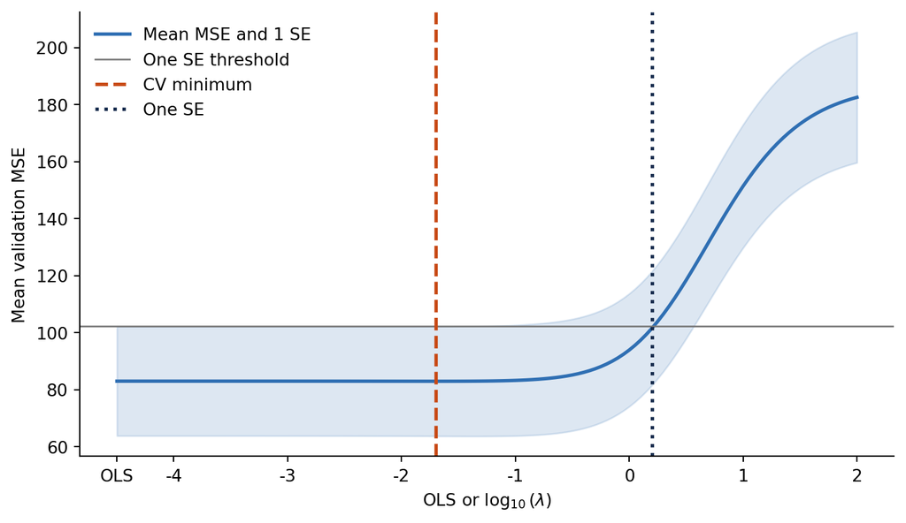

Ten-fold cross-validation over the penalty grid, with a one-standard-error band.

```
lambda_min          0.01995
cv_mean_at_min     82.97765
se_at_min          19.22991
one_se_limit      102.20756
lambda_1se          1.58489
cv_mean_at_ols     83.01239
dtype: float64
```

```python
fold_levels = np.sort(np.unique(folds))
# Rows are folds, columns are penalties.
fold_mse = np.empty((len(fold_levels), len(lambda_grid)))

for k, fold in enumerate(fold_levels):
    validation = folds == fold
    X_fold_train_raw = X_train_raw[~validation]
    X_fold_validation_raw = X_train_raw[validation]
    y_fold_train = y_train[~validation]
    y_fold_validation = y_train[validation]

    # Means and scales come from the nine fitting folds only, computed once
    # and reused for every penalty.
    x_bar = X_fold_train_raw.mean(axis=0)
    X_centered = X_fold_train_raw - x_bar
    s = np.sqrt(np.mean(X_centered**2, axis=0))
    X = X_centered / s
    X_validation = (X_fold_validation_raw - x_bar) / s

    y_bar = y_fold_train.mean()
    n, p = X.shape
    gram = X.T @ X
    rhs = X.T @ (y_fold_train - y_bar)

    for l, lam in enumerate(lambda_grid):
        beta_hat = np.linalg.solve(gram + n * lam * np.eye(p), rhs)
        y_hat_validation = y_bar + X_validation @ beta_hat
        fold_mse[k, l] = np.mean((y_fold_validation - y_hat_validation) ** 2)

cv_mean = fold_mse.mean(axis=0)
cv_se = fold_mse.std(axis=0, ddof=1) / np.sqrt(fold_mse.shape[0])
min_index = int(np.argmin(cv_mean))
lambda_min = lambda_grid[min_index]
one_se_limit = cv_mean[min_index] + cv_se[min_index]
lambda_1se = lambda_grid[cv_mean <= one_se_limit].max()

# OLS has no log position, so give it its own tick left of the grid.
positive = lambda_grid > 0
positive_log_lambda = np.log10(lambda_grid[positive])
ols_position = positive_log_lambda.min() - 0.5
plot_position = np.full(len(lambda_grid), ols_position)
plot_position[positive] = positive_log_lambda


def penalty_position(lam):
    return ols_position if lam == 0 else np.log10(lam)


fig, ax = plt.subplots(figsize=(7.5, 4.4))
ax.fill_between(
    plot_position, cv_mean - cv_se, cv_mean + cv_se, color="#2F6FB3", alpha=0.16
)
ax.plot(plot_position, cv_mean, color="#2F6FB3", linewidth=2, label="Mean MSE and 1 SE")
ax.axhline(
    one_se_limit, color="#7A7A7A", linewidth=1, label="One SE threshold"
)
ax.axvline(
    penalty_position(lambda_min),
    color="#C84A16",
    linestyle="--",
    linewidth=2,
    label="CV minimum",
)
ax.axvline(
    penalty_position(lambda_1se),
    color="#13294B",
    linestyle=":",
    linewidth=2,
    label="One SE",
)
ax.set(xlabel=r"OLS or $\log_{10}(\lambda)$", ylabel="Mean validation MSE")
ax.set_xticks(
    np.r_[ols_position, np.arange(-4, 3)],
    ["OLS", "-4", "-3", "-2", "-1", "0", "1", "2"],
)
ax.spines[["top", "right"]].set_visible(False)
ax.legend(frameon=False)
fig.tight_layout()
plt.show()

print(
    pd.Series(
        {
            "lambda_min": lambda_min,
            "cv_mean_at_min": cv_mean[min_index],
            "se_at_min": cv_se[min_index],
            "one_se_limit": one_se_limit,
            "lambda_1se": lambda_1se,
            "cv_mean_at_ols": cv_mean[0],
        }
    ).round(5)
)
```

**Answer.** Ten-fold cross-validation over the 122 candidates gives

$$\lambda_{\min}=0.019953
\qquad\text{with}\qquad
\overline{\operatorname{MSE}}(\lambda_{\min})=82.978 .$$

The standard error there is $\operatorname{SE}(\lambda_{\min})=19.230$, so the threshold is $82.978+19.230=102.208$. The largest candidate in $\Lambda$ whose mean validation MSE stays at or below it is

$$\lambda_{\mathrm{1se}}=1.584893 .$$

Two features of the curve stand out. It is almost perfectly flat from OLS through $\lambda\approx10^{-1}$, with the OLS value of $83.012$ sitting only $0.034$ above the minimum, so the data barely distinguish these penalties. The curve then climbs steeply past $\lambda\approx1$ as shrinkage begins to bite.

The standard error is large relative to that flatness. At $19.230$ it is more than $500$ times the gap between OLS and $\lambda_{\min}$, because the ten fold errors themselves vary a great deal across folds of roughly 33 observations. The band is therefore wide, and the rule selects a $\lambda$ almost eighty times larger than $\lambda_{\min}$. That is the heuristic working as designed, preferring the simplest model statistically indistinguishable from the best, but the size of the jump is worth noting: the ten fitting sets overlap heavily, so $\operatorname{SE}$ is a selection heuristic rather than an independent-sample standard error.

2. Use all $n=332$ training observations to calculate the [lecture’s GCV criterion](https://teazrq.github.io/stat432rpy/topics/ridge-regression/optimization-and-cross-validation.html#loocv-and-gcv) for each $\lambda\in\Lambda$:

$$\operatorname{GCV}(\lambda)
=
\frac{
\operatorname{MSE}_{\mathrm{train}}(\lambda)
}{
\left\{
1-\operatorname{df}_{\mathrm{eff}}(\lambda)/n
\right\}^2
}.$$

Here $\operatorname{MSE}_{\mathrm{train}}$ is the training MSE, and $\operatorname{df}_{\mathrm{eff}}$ includes the unpenalized intercept, as in Question 3. Estimate means and scales once from all training observations and keep them fixed for this calculation. Plot the GCV curve and identify $\lambda_{\mathrm{GCV}}$.

**Show the workflow**

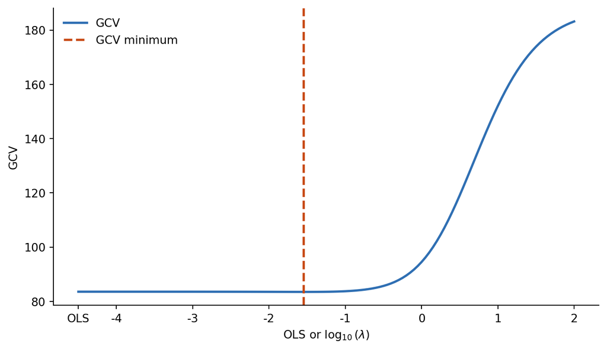

GCV over the penalty grid, computed once from all 332 training observations.

```
lambda_gcv        0.02818
gcv_at_min       83.50191
gcv_at_ols       83.58127
df_eff_at_gcv     6.68866
dtype: float64
training singular values: [29.628 18.848 17.942 14.23  13.534  7.166]
```

```python
# One fixed full-training standardization, reused across the whole grid.
x_bar = X_train_raw.mean(axis=0)
X_centered = X_train_raw - x_bar
s = np.sqrt(np.mean(X_centered**2, axis=0))
X = X_centered / s
y_bar = y_train.mean()
n, p = X.shape
gram = X.T @ X
rhs = X.T @ (y_train - y_bar)
singular_values = np.linalg.svd(X, compute_uv=False)

gcv = np.empty(len(lambda_grid))
df_eff_path = np.empty(len(lambda_grid))
for l, lam in enumerate(lambda_grid):
    beta_hat = np.linalg.solve(gram + n * lam * np.eye(p), rhs)
    y_hat = y_bar + X @ beta_hat
    df_eff_path[l] = 1 + np.sum(singular_values**2 / (singular_values**2 + n * lam))
    training_mse = np.mean((y_train - y_hat) ** 2)
    gcv[l] = training_mse / (1 - df_eff_path[l] / n) ** 2

lambda_gcv = lambda_grid[int(np.argmin(gcv))]

fig, ax = plt.subplots(figsize=(7.5, 4.4))
ax.plot(plot_position, gcv, color="#2F6FB3", linewidth=2, label="GCV")
ax.axvline(
    penalty_position(lambda_gcv),
    color="#C84A16",
    linestyle="--",
    linewidth=2,
    label="GCV minimum",
)
ax.set(xlabel=r"OLS or $\log_{10}(\lambda)$", ylabel="GCV")
ax.set_xticks(
    np.r_[ols_position, np.arange(-4, 3)],
    ["OLS", "-4", "-3", "-2", "-1", "0", "1", "2"],
)
ax.spines[["top", "right"]].set_visible(False)
ax.legend(frameon=False)
fig.tight_layout()
plt.show()

print(
    pd.Series(
        {
            "lambda_gcv": lambda_gcv,
            "gcv_at_min": gcv.min(),
            "gcv_at_ols": gcv[0],
            "df_eff_at_gcv": df_eff_path[int(np.argmin(gcv))],
        }
    ).round(5)
)
print("training singular values:", np.round(singular_values, 3))
```

**Answer.** The GCV curve is minimized at

$$\lambda_{\mathrm{GCV}}=0.028184,
\qquad
\operatorname{GCV}(\lambda_{\mathrm{GCV}})=83.502 .$$

The mechanism is visible in the formula. Training MSE increases with $\lambda$, but the denominator $\left(1-\operatorname{df}_{\mathrm{eff}}(\lambda)/n\right)^2$ also increases as the effective degrees of freedom fall from $7$ toward $1$. For small $\lambda$ the denominator correction wins slightly, which is why the minimum sits at a positive penalty rather than at OLS, where $\operatorname{GCV}=83.581$. For large $\lambda$ the rising training MSE dominates and the curve climbs sharply.

The GCV curve is much smoother than the cross-validation curve and carries no fold-to-fold variability, since it comes from a single fit. That smoothness is a presentational advantage, not evidence of greater reliability. GCV still estimates prediction error from training residuals corrected by $\operatorname{df}_{\mathrm{eff}}$, and it inherits any misspecification in the linear model.

The training singular values are $29.63$, $18.85$, $17.94$, $14.23$, $13.53$, and $7.17$, a condition number of about $4.1$. This design is well conditioned, with no direction resembling the near-collinear pair in Question 2, so no direction needs heavy shrinkage. That is consistent with both error-based criteria landing on mild penalties.

3. Fix all three choices before examining the test responses. Refit OLS and ridge at $\lambda_{\min}$, $\lambda_{\mathrm{1se}}$, and $\lambda_{\mathrm{GCV}}$ using all training observations. Report each model’s training MSE, test MSE, and effective degrees of freedom. Interpret the differences and explain why the model with the smallest observed test MSE must not be selected after viewing this table.

**TipStarter workflow**

After matching the two files by `row_id`, use this order:

```
for each validation fold:
    estimate predictor means and scales from the other nine folds
    for each lambda:
        fit on those nine folds and record validation MSE
summarize the ten fold errors and fix lambda_min and lambda_1se
compute GCV using all training observations and fix lambda_GCV
only then refit the four reported models and evaluate the test responses
```

**Show the workflow**

```python
# Every penalty was fixed above using training information only.
selected = pd.DataFrame(
    {
        "rule": ["OLS", "CV minimum", "One SE", "GCV"],
        "lambda": [0.0, lambda_min, lambda_1se, lambda_gcv],
    }
)
selected[["df_eff", "train_mse", "test_mse"]] = np.nan

for l, lam in enumerate(selected["lambda"]):
    fit = fit_ridge(X_train_raw, y_train, lam, X_test_raw)
    selected.loc[l, "df_eff"] = fit["df_eff"]
    selected.loc[l, "train_mse"] = np.mean((y_train - fit["y_hat"]) ** 2)
    selected.loc[l, "test_mse"] = np.mean((y_test - fit["y_hat_new"]) ** 2)

print(selected.round(5).to_string(index=False))
```

```
      rule  lambda  df_eff  train_mse  test_mse
       OLS 0.00000 7.00000   80.09392  66.32246
CV minimum 0.01995 6.77321   80.13543  65.99957
    One SE 1.58489 3.03287  100.37356  81.19981
       GCV 0.02818 6.68866   80.17125  65.90276
```

**Answer.** The final comparison is

| Rule | $\lambda$ | Effective df | Training MSE | Test MSE |
| --- | --- | --- | --- | --- |
| OLS | 0 | 7.000 | 80.094 | 66.322 |
| CV minimum | 0.019953 | 6.773 | 80.135 | 65.999 |
| One SE | 1.584893 | 3.033 | 100.374 | 81.200 |
| GCV | 0.028184 | 6.689 | 80.171 | 65.903 |

OLS has the smallest training MSE, as it must, since it minimizes exactly that quantity using the full $p+1=7$ degrees of freedom. Training MSE rises monotonically with $\lambda$ across the table, which is why it can never be used to select a penalty.

The CV-minimum and GCV fits apply mild shrinkage, giving up about $0.23$ and $0.31$ effective degrees of freedom. Their training MSEs are nearly identical to OLS, and both improve slightly on the test set, from $66.322$ to $65.999$ and $65.903$. The improvement is small because this design is well conditioned, as part (b) showed. With no near-collinear direction of the kind seen in Question 2, there is little excess variance available for ridge to remove.

The one-standard-error model is different in kind. It cuts the effective degrees of freedom from $7$ to $3.033$, so more than half the model’s flexibility is gone. Training MSE rises by $25\%$ and test MSE by $22\%$, to $81.200$. Both move in the same direction, which is the signature of bias rather than variance: the fit is now too constrained to capture structure genuinely present in the data. The rule was drawn to this penalty by the wide standard error in part (a), not by evidence that heavy shrinkage helps here.

**Why the smallest observed test MSE must not be selected.** GCV shows the lowest test MSE at $65.903$, but adopting GCV on that basis would invalidate the number. The three penalties were fixed using training data alone, and that is precisely what makes the test set a valid estimate of future performance. Choosing among the four rules by comparing test MSE turns the test set into a fourth selection stage. The minimum of four noisy estimates is biased downward as an estimate of the performance of the rule that produced it, so the reported $65.903$ would become optimistic by an unknown amount, with no held-out data left to correct it.

The size of the difference reinforces the point. GCV beats the CV minimum by $0.096$ on 82 test observations, far smaller than the fold-to-fold variability seen in part (a). A slightly different train-test split could easily reverse that ordering, so the ranking between the two carries essentially no information. What the table legitimately supports is the weaker and more useful conclusion that mild shrinkage chosen by either error-based criterion performs about as well as OLS on this data, and that the one-standard-error rule over-regularizes this particular problem. Had a decision been required, it should have been made before the test responses were read.

Two further cautions apply. GCV is not an independent check on cross-validation, since it estimates prediction error from the same training fit by correcting training residuals with $\operatorname{df}_{\mathrm{eff}}$. Its agreement with $\lambda_{\min}$ shows that two training-based criteria see the same curve, not that either has been externally validated. And ridge only controls coefficient variance within the specified linear model. It cannot repair nonlinearity, omitted variables, or other misspecification, and a test MSE near $66$ against a response variance of roughly $185$ leaves room for all three.

## `explain-to-me` skill

The complete contents of `explain-to-me/SKILL.md`:

```markdown
---
name: explain-to-me
description: Use when I explicitly ask for help understanding a STAT 432 homework question. Explains what the question is asking without solving any part of it.
---

# Intent

I want to understand what a homework question is asking before I attempt it.
Explain the question to me. The mathematical, computational, and written work
stays mine.

# Instructions

- Read the entire question before replying, including any setup that appears
  before the lettered parts. That setup usually carries the notation and
  conventions the parts depend on.
- State the goal of the question in one or two sentences of plain language.
- For each part, say what kind of thing I have to produce: a derivation, a
  number, a plot, a table, or a written interpretation.
- Keep the question's own notation. Do not rename or redefine symbols.
- Name the one concept I need in order to start, and point me to a specific
  section of the relevant Week 3 lecture:
  - Questions 2 and 3: [Ridge Regression: Stability Through Shrinkage](https://teazrq.github.io/stat432rpy/topics/ridge-regression/ridge-regression.html)
  - Questions 4 and 5: [From a Penalized Objective to a Fitted Ridge Model](https://teazrq.github.io/stat432rpy/topics/ridge-regression/optimization-and-cross-validation.html)

  If you cannot read the page, say so rather than inventing a section title.
- Suggest a first step, then stop and ask me which part is still unclear.
- Keep the whole reply under roughly 300 words.

# Never

- Do not carry out derivations, algebra, or numerical calculations.
- Do not write solution code, pseudocode, or the sequence of fitting steps.
- Do not state the final answer, even partially.
- Do not confirm or reject an answer I propose. Ask me how I got it instead.
```

## Reference

The real-estate data come from I-Cheng Yeh’s [Real Estate Valuation dataset](https://archive.ics.uci.edu/dataset/477/real%2Bestate%2Bvaluation%2Bda) in the UCI Machine Learning Repository. The distributed data retain the original observations and add only the course train-test and fold assignments.